# Size symbolism in production and perception

```r
summary(m_fpeak)
```

```
##  Family: gaussian
##   Links: mu = identity
## Formula: fric_peak_Hz ~ size_c * animacy_c + phoneme + (1 + size_c | speaker) + (1 | item_english)
##    Data: data (Number of observations: 2471)
##   Draws: 4 chains, each with iter = 8000; warmup = 4000; thin = 1;
##          total post-warmup draws = 16000
##
## Multilevel Hyperparameters:
## ~item_english (Number of levels: 36)
##               Estimate Est.Error l-95% CI u-95% CI Rhat Bulk_ESS Tail_ESS
## sd(Intercept)   154.77    101.20     7.34   369.88 1.00     3956     6559
##
## ~speaker (Number of levels: 42)
##                       Estimate Est.Error l-95% CI u-95% CI Rhat Bulk_ESS
## sd(Intercept)           760.68    109.05   571.88   999.86 1.00     5781
## sd(size_c)               84.49     73.05     3.28   272.66 1.00    12297
## cor(Intercept,size_c)    -0.09      0.55    -0.95     0.93 1.00    19740
##                       Tail_ESS
## sd(Intercept)            10186
## sd(size_c)                8251
## cor(Intercept,size_c)     9442
##
## Regression Coefficients:
##                  Estimate Est.Error l-95% CI u-95% CI Rhat Bulk_ESS Tail_ESS
## Intercept         6327.58    145.38  6040.02  6609.25 1.00     5461     8412
## size_c              27.04     82.07  -132.25   186.16 1.00    23208    11654
## animacy_c           45.61     80.54  -115.08   202.58 1.00    24599    12253
## phonemef           584.17     81.80   425.58   743.79 1.00    24763    12142
## phonemeS          -274.07     94.70  -459.22   -86.65 1.00    28804    11974
## phonemez           678.08     83.62   516.35   838.91 1.00    24039    12235
## size_c:animacy_c    13.62     93.32  -170.69   195.33 1.00    25254    11273
##
## Further Distributional Parameters:
##       Estimate Est.Error l-95% CI u-95% CI Rhat Bulk_ESS Tail_ESS
## sigma  3109.77     46.34  3021.52  3201.25 1.00    21392    12281
##
## Draws were sampled using sample(hmc). For each parameter, Bulk_ESS
## and Tail_ESS are effective sample size measures, and Rhat is the potential
## scale reduction factor on split chains (at convergence, Rhat = 1).
```

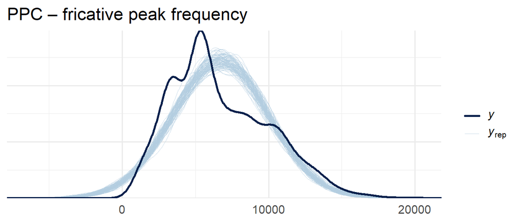

**Figure 23.** Posterior predictive check for fricative peak frequency (Gaussian).

```r
pp_check(m_fpeak, ndraws = 100) + ggtitle("PPC – fricative peak frequency")
```

```r
summary(m_fCoG)
```

```
##  Family: gaussian
##   Links: mu = identity
## Formula: fric_CoG_Hz ~ size_c * animacy_c + phoneme + (1 + size_c | speaker) + (1 | item_english)
##    Data: data (Number of observations: 2471)
##   Draws: 4 chains, each with iter = 8000; warmup = 4000; thin = 1;
##          total post-warmup draws = 16000
##
## Multilevel Hyperparameters:
## ~item_english (Number of levels: 36)
##               Estimate Est.Error l-95% CI u-95% CI Rhat Bulk_ESS Tail_ESS
## sd(Intercept)   284.37     76.93   132.51   436.14 1.00     5072     3953
##
## ~speaker (Number of levels: 42)
##                       Estimate Est.Error l-95% CI u-95% CI Rhat Bulk_ESS
## sd(Intercept)           913.62    118.65   709.10  1173.58 1.00     4197
## sd(size_c)              114.78    105.58     3.90   397.54 1.00     6723
## cor(Intercept,size_c)     0.05      0.51    -0.91     0.93 1.00    22265
##                       Tail_ESS
## sd(Intercept)             8238
## sd(size_c)                7326
## cor(Intercept,size_c)    10364
##
## Regression Coefficients:
##                  Estimate Est.Error l-95% CI u-95% CI Rhat Bulk_ESS Tail_ESS
## Intercept         5824.11    163.31  5500.49  6143.06 1.00     3864     6475
## size_c             -50.14     81.34  -207.86   109.95 1.00    23009    13434
## animacy_c           53.10     80.44  -106.93   209.81 1.00    21000    12733
## phonemef          1050.80     75.21   904.91  1198.48 1.00    30232    12925
## phonemeS          -199.48     89.96  -376.17   -24.75 1.00    34403    11428
## phonemez           582.04     76.00   432.81   730.16 1.00    31965    11860
## size_c:animacy_c   -17.59     95.35  -204.14   167.36 1.00    32199    11339
##
## Further Distributional Parameters:
##       Estimate Est.Error l-95% CI u-95% CI Rhat Bulk_ESS Tail_ESS
## sigma  2347.11     36.06  2277.68  2419.13 1.00    25921    12301
##
## Draws were sampled using sample(hmc). For each parameter, Bulk_ESS
## and Tail_ESS are effective sample size measures, and Rhat is the potential
## scale reduction factor on split chains (at convergence, Rhat = 1).
```

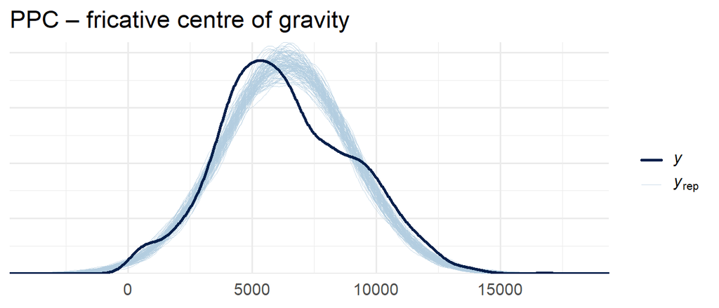

**Figure 24.** Posterior predictive check for fricative centre of gravity (Gaussian).

```r
pp_check(m_fCoG, ndraws = 100) + ggtitle("PPC – fricative centre of gravity")
```

## 7.4 Perception of exploratory features

These models mirror §6.4–6.5 but swap the acoustic predictor. Each tests whether listeners use the speaker’s exploratory feature (z-scored within speaker) to call “big”. As before the interaction with `animacy_c` is included so the perception models can answer both whether the cue matters on average *and* whether animacy modulates its use.

```r
m_perc_F1     <- fit_perc_bin("big_judgment", "F1_mean_z")
```

```
## [fit_brm] Cache exists at 'm_perc_big_judgment_F1_mean_z.rds' – brms will reuse it if formula/data/prior match.
```

```r
m_perc_F2     <- fit_perc_bin("big_judgment", "F2_mean_z")
```

```
## [fit_brm] Cache exists at 'm_perc_big_judgment_F2_mean_z.rds' – brms will reuse it if formula/data/prior match.
```

```r
m_perc_CPP   <- fit_perc_bin("big_judgment", "CPP_mean_z")
```

```
## [fit_brm] Cache exists at 'm_perc_big_judgment_CPP_mean_z.rds' – brms will reuse it if formula/data/prior match.
```

```r
m_perc_H1H2  <- fit_perc_bin("big_judgment", "H1H2_mean_z")
```

```
## [fit_brm] Cache exists at 'm_perc_big_judgment_H1H2_mean_z.rds' – brms will reuse it if formula/data/prior match.
```

```r
m_perc_fCoG  <- fit_perc_bin("big_judgment", "fric_CoG_Hz_mean_z")
```

```
## [fit_brm] Cache exists at 'm_perc_big_judgment_fric_CoG_Hz_mean_z.rds' – brms will reuse it if formula/data/prior match.
```

```r
m_perc_fdur   <- fit_perc_bin("big_judgment", "fric_dur_ms_mean_z")
```

```
## [fit_brm] Cache exists at 'm_perc_big_judgment_fric_dur_ms_mean_z.rds' – brms will reuse it if formula/data/prior match.
```

```r
m_perc_fSPL   <- fit_perc_bin("big_judgment", "fric_SPL_dB_mean_z")
```

```
## [fit_brm] Cache exists at 'm_perc_big_judgment_fric_SPL_dB_mean_z.rds' – brms will reuse it if formula/data/prior match.
```

```r
m_perc_fpeak  <- fit_perc_bin("big_judgment", "fric_peak_Hz_mean_z")
```

```
## [fit_brm] Cache exists at 'm_perc_big_judgment_fric_peak_Hz_mean_z.rds' – brms will reuse it if formula/data/prior match.
```

```r
summary(m_perc_F1)
```

```
##  Family: bernoulli
##   Links: mu = logit
## Formula: big_judgment ~ F1_mean_z * animacy_c + (1 | listener) + (1 | speaker) + (1 | item_english)
##    Data: data (Number of observations: 916)
##   Draws: 4 chains, each with iter = 8000; warmup = 4000; thin = 1;
##          total post-warmup draws = 16000
##
## Multilevel Hyperparameters:
## ~item_english (Number of levels: 36)
##               Estimate Est.Error l-95% CI u-95% CI Rhat Bulk_ESS Tail_ESS
## sd(Intercept)     1.83      0.29     1.35     2.47 1.00     5085     8800
##
## ~listener (Number of levels: 39)
##               Estimate Est.Error l-95% CI u-95% CI Rhat Bulk_ESS Tail_ESS
## sd(Intercept)     0.11      0.08     0.00     0.30 1.00    10831     8064
##
## ~speaker (Number of levels: 39)
##               Estimate Est.Error l-95% CI u-95% CI Rhat Bulk_ESS Tail_ESS
## sd(Intercept)     0.13      0.10     0.01     0.36 1.00     8631     8410
##
## Regression Coefficients:
##                     Estimate Est.Error l-95% CI u-95% CI Rhat Bulk_ESS Tail_ESS
## Intercept              -0.11      0.32    -0.76     0.52 1.00     3296     6366
## F1_mean_z              -0.08      0.09    -0.26     0.11 1.00    33460    12281
## animacy_c              -0.93      0.64    -2.20     0.31 1.00     3550     6401
## F1_mean_z:animacy_c    -0.11      0.19    -0.48     0.25 1.00    32454    11657
##
## Draws were sampled using sample(hmc). For each parameter, Bulk_ESS
## and Tail_ESS are effective sample size measures, and Rhat is the potential
## scale reduction factor on split chains (at convergence, Rhat = 1).
```

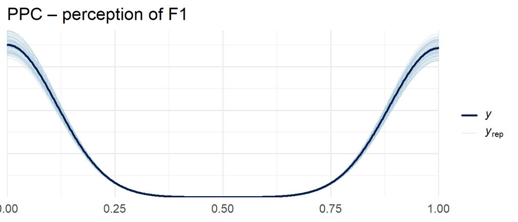

**Figure 25.** Perception: F1 as cue to ‘big’ judgment.

```r
pp_check(m_perc_F1, ndraws = 100) + ggtitle("PPC – perception of F1")
```

```r
summary(m_perc_F2)
```

```
##  Family: bernoulli
##   Links: mu = logit
## Formula: big_judgment ~ F2_mean_z * animacy_c + (1 | listener) + (1 | speaker) + (1 | item_english)
##    Data: data (Number of observations: 916)
##   Draws: 4 chains, each with iter = 8000; warmup = 4000; thin = 1;
##          total post-warmup draws = 16000
##
## Multilevel Hyperparameters:
## ~item_english (Number of levels: 36)
##               Estimate Est.Error l-95% CI u-95% CI Rhat Bulk_ESS Tail_ESS
## sd(Intercept)     1.84      0.29     1.37     2.49 1.00     4574     8032
##
## ~listener (Number of levels: 39)
##               Estimate Est.Error l-95% CI u-95% CI Rhat Bulk_ESS Tail_ESS
## sd(Intercept)     0.11      0.08     0.00     0.30 1.00    10706     7997
##
## ~speaker (Number of levels: 39)
##               Estimate Est.Error l-95% CI u-95% CI Rhat Bulk_ESS Tail_ESS
## sd(Intercept)     0.13      0.10     0.01     0.36 1.00     7900     7693
##
## Regression Coefficients:
##                     Estimate Est.Error l-95% CI u-95% CI Rhat Bulk_ESS Tail_ESS
## Intercept              -0.10      0.33    -0.77     0.55 1.00     2779     5249
## F2_mean_z               0.01      0.09    -0.17     0.18 1.00    28234    12561
## animacy_c              -0.98      0.65    -2.29     0.30 1.00     2794     4974
## F2_mean_z:animacy_c    -0.04      0.19    -0.40     0.34 1.00    26450    12269
##
## Draws were sampled using sample(hmc). For each parameter, Bulk_ESS
## and Tail_ESS are effective sample size measures, and Rhat is the potential
## scale reduction factor on split chains (at convergence, Rhat = 1).
```

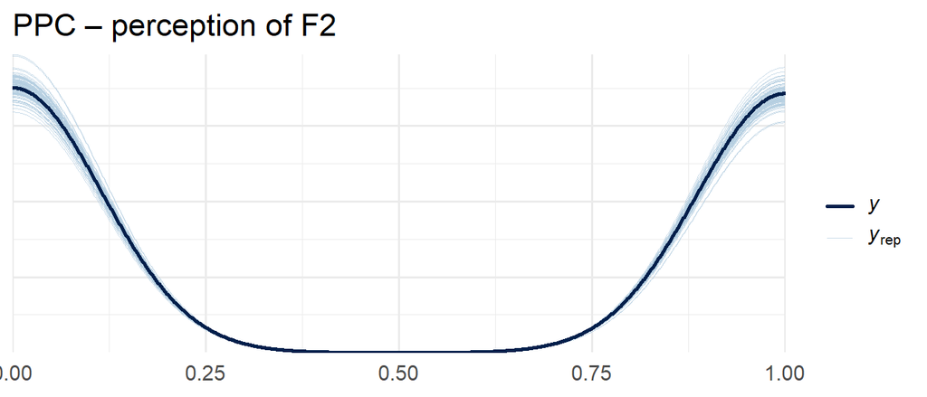

**Figure 26.** Perception: F2 as cue to ‘big’ judgment.

```r
pp_check(m_perc_F2, ndraws = 100) + ggtitle("PPC – perception of F2")
```

```r
summary(m_perc_CPP)
```

```
##  Family: bernoulli
##   Links: mu = logit
## Formula: big_judgment ~ CPP_mean_z * animacy_c + (1 | listener) + (1 | speaker) + (1 | item_english)
##    Data: data (Number of observations: 916)
##   Draws: 4 chains, each with iter = 8000; warmup = 4000; thin = 1;
##          total post-warmup draws = 16000
##
## Multilevel Hyperparameters:
## ~item_english (Number of levels: 36)
##               Estimate Est.Error l-95% CI u-95% CI Rhat Bulk_ESS Tail_ESS
## sd(Intercept)     1.86      0.29     1.38     2.51 1.00     4451     8838
##
## ~listener (Number of levels: 39)
##               Estimate Est.Error l-95% CI u-95% CI Rhat Bulk_ESS Tail_ESS
## sd(Intercept)     0.11      0.08     0.00     0.30 1.00    10111     7760
##
## ~speaker (Number of levels: 39)
##               Estimate Est.Error l-95% CI u-95% CI Rhat Bulk_ESS Tail_ESS
## sd(Intercept)     0.13      0.10     0.01     0.36 1.00     7468     7411
##
## Regression Coefficients:
##                      Estimate Est.Error l-95% CI u-95% CI Rhat Bulk_ESS
## Intercept               -0.10      0.33    -0.75     0.56 1.00     2679
## CPP_mean_z              -0.09      0.09    -0.27     0.09 1.00    25215
## animacy_c               -0.99      0.66    -2.31     0.28 1.00     2655
## CPP_mean_z:animacy_c     0.10      0.18    -0.26     0.46 1.00    27431
##                      Tail_ESS
## Intercept                4746
## CPP_mean_z              11849
## animacy_c                5123
## CPP_mean_z:animacy_c    12938
##
## Draws were sampled using sample(hmc). For each parameter, Bulk_ESS
## and Tail_ESS are effective sample size measures, and Rhat is the potential
## scale reduction factor on split chains (at convergence, Rhat = 1).
```

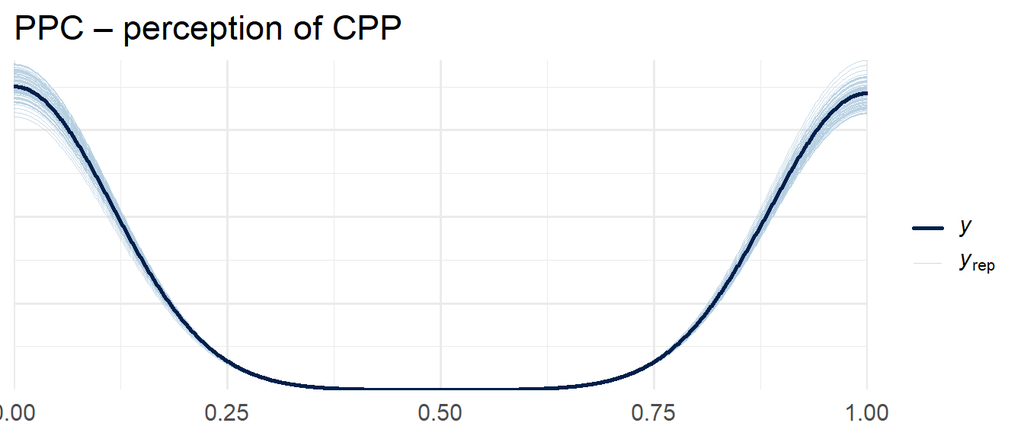

**Figure 27.** Perception: CPP as cue to ‘big’ judgment.

```r
pp_check(m_perc_CPP, ndraws = 100) + ggtitle("PPC – perception of CPP")
```

```r
summary(m_perc_H1H2)
```

```
##  Family: bernoulli
##   Links: mu = logit
## Formula: big_judgment ~ H1H2_mean_z * animacy_c + (1 | listener) + (1 | speaker) + (1 | item_english)
##    Data: data (Number of observations: 916)
##   Draws: 4 chains, each with iter = 8000; warmup = 4000; thin = 1;
##          total post-warmup draws = 16000
##
## Multilevel Hyperparameters:
## ~item_english (Number of levels: 36)
##               Estimate Est.Error l-95% CI u-95% CI Rhat Bulk_ESS Tail_ESS
## sd(Intercept)     1.85      0.29     1.37     2.49 1.00     5025     8443
##
## ~listener (Number of levels: 39)
##               Estimate Est.Error l-95% CI u-95% CI Rhat Bulk_ESS Tail_ESS
## sd(Intercept)     0.10      0.08     0.00     0.30 1.00    11169     8952
##
## ~speaker (Number of levels: 39)
##               Estimate Est.Error l-95% CI u-95% CI Rhat Bulk_ESS Tail_ESS
## sd(Intercept)     0.13      0.09     0.01     0.35 1.00     9022     8581
##
## Regression Coefficients:
##                       Estimate Est.Error l-95% CI u-95% CI Rhat Bulk_ESS
## Intercept                -0.11      0.32    -0.75     0.52 1.00     3542
## H1H2_mean_z               0.03      0.09    -0.15     0.21 1.00    31819
## animacy_c                -0.96      0.65    -2.24     0.34 1.00     3599
## H1H2_mean_z:animacy_c     0.16      0.19    -0.21     0.52 1.00    30179
##                       Tail_ESS
## Intercept                 6601
## H1H2_mean_z              12619
## animacy_c                 6355
## H1H2_mean_z:animacy_c    11020
##
## Draws were sampled using sample(hmc). For each parameter, Bulk_ESS
## and Tail_ESS are effective sample size measures, and Rhat is the potential
## scale reduction factor on split chains (at convergence, Rhat = 1).
```

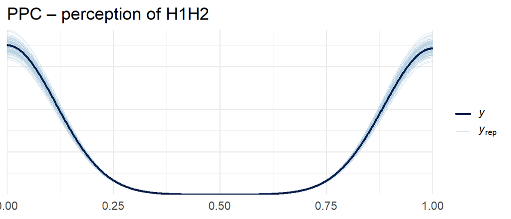

**Figure 28.** Perception: H1H2 as cue to ‘big’ judgment.

```r
pp_check(m_perc_H1H2, ndraws = 100) + ggtitle("PPC – perception of H1H2")
```

```r
summary(m_perc_fCoG)
```

```
##  Family: bernoulli
##   Links: mu = logit
## Formula: big_judgment ~ fric_CoG_Hz_mean_z * animacy_c + (1 | listener) + (1 | speaker) + (1 | item_english)
##    Data: data (Number of observations: 916)
##   Draws: 4 chains, each with iter = 8000; warmup = 4000; thin = 1;
##          total post-warmup draws = 16000
##
## Multilevel Hyperparameters:
## ~item_english (Number of levels: 36)
##               Estimate Est.Error l-95% CI u-95% CI Rhat Bulk_ESS Tail_ESS
## sd(Intercept)     1.84      0.29     1.37     2.49 1.00     4538     8506
##
## ~listener (Number of levels: 39)
##               Estimate Est.Error l-95% CI u-95% CI Rhat Bulk_ESS Tail_ESS
## sd(Intercept)     0.11      0.08     0.00     0.30 1.00     9874     7589
##
## ~speaker (Number of levels: 39)
##               Estimate Est.Error l-95% CI u-95% CI Rhat Bulk_ESS Tail_ESS
## sd(Intercept)     0.13      0.10     0.01     0.37 1.00     8122     8276
##
## Regression Coefficients:
##                              Estimate Est.Error l-95% CI u-95% CI Rhat Bulk_ESS
## Intercept                       -0.09      0.33    -0.74     0.54 1.00     2873
## fric_CoG_Hz_mean_z              -0.03      0.09    -0.22     0.15 1.00    27974
## animacy_c                       -0.96      0.64    -2.24     0.31 1.00     2931
## fric_CoG_Hz_mean_z:animacy_c    -0.29      0.19    -0.66     0.07 1.00    26860
##                              Tail_ESS
## Intercept                        5024
## fric_CoG_Hz_mean_z              12321
## animacy_c                        5408
## fric_CoG_Hz_mean_z:animacy_c    12316
##
## Draws were sampled using sample(hmc). For each parameter, Bulk_ESS
## and Tail_ESS are effective sample size measures, and Rhat is the potential
## scale reduction factor on split chains (at convergence, Rhat = 1).
```

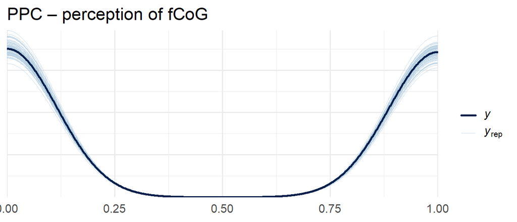

**Figure 29.** Perception: fCoG as cue to ‘big’ judgment.

```r
pp_check(m_perc_fCoG, ndraws = 100) + ggtitle("PPC – perception of fCoG")
```

```r
summary(m_perc_fdur)
```

```
##  Family: bernoulli
##   Links: mu = logit
## Formula: big_judgment ~ fric_dur_ms_mean_z * animacy_c + (1 | listener) + (1 | speaker) + (1 | item_english)
##    Data: data (Number of observations: 916)
##   Draws: 4 chains, each with iter = 8000; warmup = 4000; thin = 1;
##          total post-warmup draws = 16000
##
## Multilevel Hyperparameters:
## ~item_english (Number of levels: 36)
##               Estimate Est.Error l-95% CI u-95% CI Rhat Bulk_ESS Tail_ESS
## sd(Intercept)     1.82      0.29     1.35     2.46 1.00     5872     9126
##
## ~listener (Number of levels: 39)
##               Estimate Est.Error l-95% CI u-95% CI Rhat Bulk_ESS Tail_ESS
## sd(Intercept)     0.10      0.08     0.00     0.30 1.00    10753     8630
##
## ~speaker (Number of levels: 39)
##               Estimate Est.Error l-95% CI u-95% CI Rhat Bulk_ESS Tail_ESS
## sd(Intercept)     0.13      0.10     0.00     0.36 1.00     9395     8781
##
## Regression Coefficients:
##                              Estimate Est.Error l-95% CI u-95% CI Rhat Bulk_ESS
## Intercept                       -0.12      0.33    -0.78     0.52 1.00     3584
## fric_dur_ms_mean_z               0.25      0.11     0.04     0.45 1.00    24727
## animacy_c                       -0.95      0.64    -2.22     0.29 1.00     3698
## fric_dur_ms_mean_z:animacy_c     0.50      0.21     0.09     0.91 1.00    26600
##                              Tail_ESS
## Intercept                        6599
## fric_dur_ms_mean_z              12496
## animacy_c                        6903
## fric_dur_ms_mean_z:animacy_c    13246
##
## Draws were sampled using sample(hmc). For each parameter, Bulk_ESS
## and Tail_ESS are effective sample size measures, and Rhat is the potential
## scale reduction factor on split chains (at convergence, Rhat = 1).
```

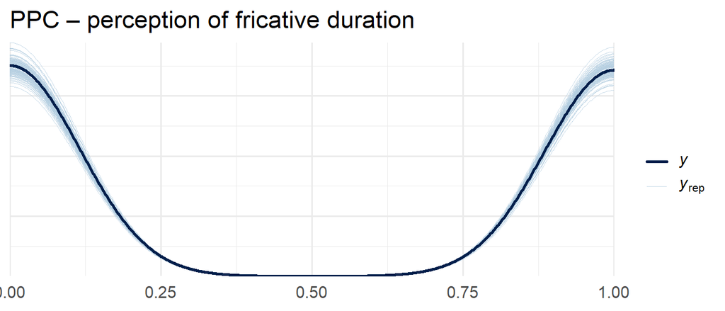

**Figure 30.** Perception: fricative duration as cue to ‘big’ judgment.

```r
pp_check(m_perc_fdur, ndraws = 100) + ggtitle("PPC – perception of fricative duration")
```

```r
summary(m_perc_fSPL)
```

```
##  Family: bernoulli
##   Links: mu = logit
## Formula: big_judgment ~ fric_SPL_dB_mean_z * animacy_c + (1 | listener) + (1 | speaker) + (1 | item_english)
##    Data: data (Number of observations: 916)
##   Draws: 4 chains, each with iter = 8000; warmup = 4000; thin = 1;
##          total post-warmup draws = 16000
##
## Multilevel Hyperparameters:
## ~item_english (Number of levels: 36)
##               Estimate Est.Error l-95% CI u-95% CI Rhat Bulk_ESS Tail_ESS
## sd(Intercept)     1.79      0.28     1.33     2.41 1.00     4948     8799
##
## ~listener (Number of levels: 39)
##               Estimate Est.Error l-95% CI u-95% CI Rhat Bulk_ESS Tail_ESS
## sd(Intercept)     0.11      0.08     0.00     0.30 1.00     9679     8493
##
## ~speaker (Number of levels: 39)
##               Estimate Est.Error l-95% CI u-95% CI Rhat Bulk_ESS Tail_ESS
## sd(Intercept)     0.13      0.10     0.01     0.35 1.00     8018     7748
##
## Regression Coefficients:
##                              Estimate Est.Error l-95% CI u-95% CI Rhat Bulk_ESS
## Intercept                       -0.10      0.32    -0.74     0.52 1.00     2769
## fric_SPL_dB_mean_z               0.24      0.10     0.05     0.43 1.00    28388
## animacy_c                       -0.98      0.63    -2.22     0.26 1.00     3286
## fric_SPL_dB_mean_z:animacy_c    -0.21      0.20    -0.59     0.18 1.00    26885
##                              Tail_ESS
## Intercept                        5288
## fric_SPL_dB_mean_z              12153
## animacy_c                        6029
## fric_SPL_dB_mean_z:animacy_c    11920
##
## Draws were sampled using sample(hmc). For each parameter, Bulk_ESS
## and Tail_ESS are effective sample size measures, and Rhat is the potential
## scale reduction factor on split chains (at convergence, Rhat = 1).
```

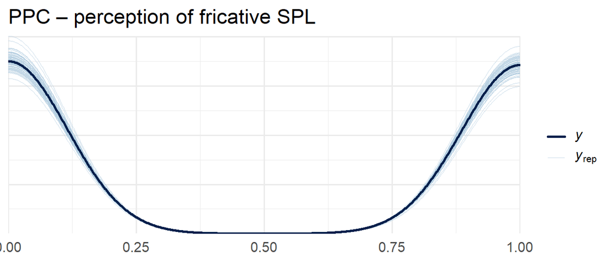

**Figure 31.** Perception: fricative SPL as cue to ‘big’ judgment.

```r
pp_check(m_perc_fSPL, ndraws = 100) + ggtitle("PPC – perception of fricative SPL")
```

```r
summary(m_perc_fpeak)
```

```
##  Family: bernoulli
##   Links: mu = logit
## Formula: big_judgment ~ fric_peak_Hz_mean_z * animacy_c + (1 | listener) + (1 | speaker) + (1 | item_english)
##    Data: data (Number of observations: 916)
##   Draws: 4 chains, each with iter = 8000; warmup = 4000; thin = 1;
##          total post-warmup draws = 16000
##
## Multilevel Hyperparameters:
## ~item_english (Number of levels: 36)
##               Estimate Est.Error l-95% CI u-95% CI Rhat Bulk_ESS Tail_ESS
## sd(Intercept)     1.85      0.29     1.37     2.49 1.00     5112     8699
##
## ~listener (Number of levels: 39)
##               Estimate Est.Error l-95% CI u-95% CI Rhat Bulk_ESS Tail_ESS
## sd(Intercept)     0.11      0.08     0.00     0.31 1.00     9620     8297
##
## ~speaker (Number of levels: 39)
##               Estimate Est.Error l-95% CI u-95% CI Rhat Bulk_ESS Tail_ESS
## sd(Intercept)     0.13      0.10     0.01     0.37 1.00     7552     8222
##
## Regression Coefficients:
##                               Estimate Est.Error l-95% CI u-95% CI Rhat
## Intercept                        -0.10      0.33    -0.76     0.55 1.00
## fric_peak_Hz_mean_z              -0.01      0.09    -0.19     0.17 1.00
## animacy_c                        -0.95      0.65    -2.23     0.32 1.00
## fric_peak_Hz_mean_z:animacy_c    -0.35      0.19    -0.72     0.02 1.00
##                               Bulk_ESS Tail_ESS
## Intercept                         2843     5728
## fric_peak_Hz_mean_z              28917    12153
## animacy_c                         2953     5747
## fric_peak_Hz_mean_z:animacy_c    28022    12487
##
## Draws were sampled using sample(hmc). For each parameter, Bulk_ESS
## and Tail_ESS are effective sample size measures, and Rhat is the potential
## scale reduction factor on split chains (at convergence, Rhat = 1).
```

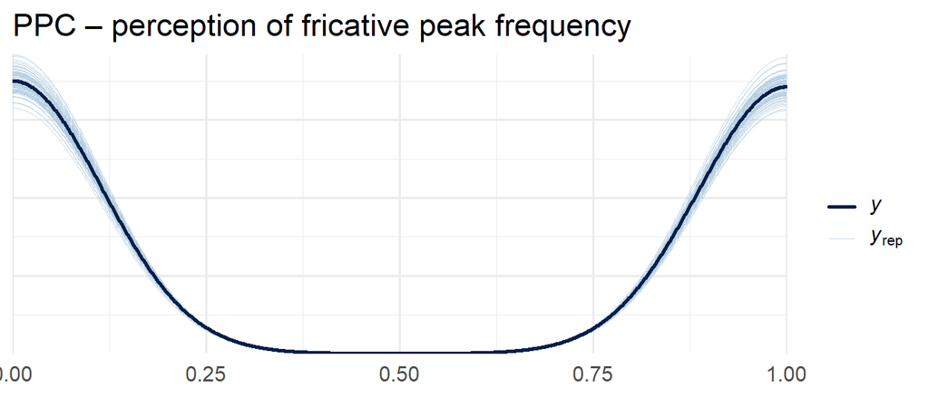

**Figure 32.** Perception: fricative peak frequency as cue to ‘big’ judgment.

```r
pp_check(m_perc_fpeak, ndraws = 100) + ggtitle("PPC – perception of fricative peak frequency")
```

## 7.5 Does the *animacy* judgment depend on acoustic cues?

These two models flip the perception outcome from “big” to “animate” and ask whether listeners draw on vowel duration or f0 to decide whether they are hearing an animal. Treating animacy as an outcome here is sound-symbolism in the broader sense: the same acoustic dimensions that encode size might also leak into the animate/inanimate distinction.

```r
m_anim_dur <- fit_perc_bin("animate_judgment", "vowel_dur_ms_mean_z")
```

```
## [fit_brm] Cache exists at 'm_perc_animate_judgment_vowel_dur_ms_mean_z.rds' – brms will reuse it if formula/data/prior match.
```

```r
m_anim_f0  <- fit_perc_bin("animate_judgment", "f0_mean_z")
```

```
## [fit_brm] Cache exists at 'm_perc_animate_judgment_f0_mean_z.rds' – brms will reuse it if formula/data/prior match.
```

```r
summary(m_anim_dur)
```

```
##  Family: bernoulli
##   Links: mu = logit
## Formula: animate_judgment ~ vowel_dur_ms_mean_z * animacy_c + (1 | listener) + (1 | speaker) + (1 | item_english)
##    Data: data (Number of observations: 916)
##   Draws: 4 chains, each with iter = 8000; warmup = 4000; thin = 1;
##          total post-warmup draws = 16000
##
## Multilevel Hyperparameters:
## ~item_english (Number of levels: 36)
##               Estimate Est.Error l-95% CI u-95% CI Rhat Bulk_ESS Tail_ESS
## sd(Intercept)     0.75      0.15     0.49     1.07 1.00     7570    10874
##
## ~listener (Number of levels: 39)
##               Estimate Est.Error l-95% CI u-95% CI Rhat Bulk_ESS Tail_ESS
## sd(Intercept)     0.21      0.14     0.01     0.50 1.00     4280     7417
##
## ~speaker (Number of levels: 39)
##               Estimate Est.Error l-95% CI u-95% CI Rhat Bulk_ESS Tail_ESS
## sd(Intercept)     0.40      0.15     0.07     0.70 1.00     3580     3681
##
## Regression Coefficients:
##                               Estimate Est.Error l-95% CI u-95% CI Rhat
## Intercept                         0.27      0.17    -0.06     0.61 1.00
## vowel_dur_ms_mean_z              -0.10      0.09    -0.28     0.09 1.00
## animacy_c                         2.15      0.31     1.56     2.78 1.00
## vowel_dur_ms_mean_z:animacy_c     0.04      0.19    -0.33     0.41 1.00
##                               Bulk_ESS Tail_ESS
## Intercept                         9765    11988
## vowel_dur_ms_mean_z              26105    11711
## animacy_c                         9104    11639
## vowel_dur_ms_mean_z:animacy_c    26617    12898
##
## Draws were sampled using sample(hmc). For each parameter, Bulk_ESS
## and Tail_ESS are effective sample size measures, and Rhat is the potential
## scale reduction factor on split chains (at convergence, Rhat = 1).
```

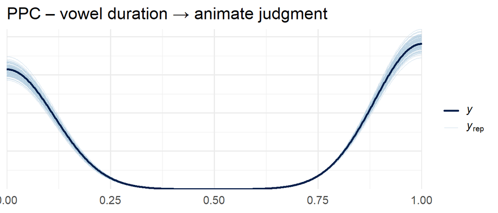

**Figure 33.** Perception: vowel duration as cue to animacy judgment.

```r
pp_check(m_anim_dur, ndraws = 100) + ggtitle("PPC – vowel duration → animate judgment")
```

```r
summary(m_anim_f0)
```

```
##  Family: bernoulli
##   Links: mu = logit
## Formula: animate_judgment ~ f0_mean_z * animacy_c + (1 | listener) + (1 | speaker) + (1 | item_english)
##    Data: data (Number of observations: 916)
##   Draws: 4 chains, each with iter = 8000; warmup = 4000; thin = 1;
##          total post-warmup draws = 16000
##
## Multilevel Hyperparameters:
## ~item_english (Number of levels: 36)
##               Estimate Est.Error l-95% CI u-95% CI Rhat Bulk_ESS Tail_ESS
## sd(Intercept)     0.72      0.15     0.47     1.04 1.00     7140    10883
##
## ~listener (Number of levels: 39)
##               Estimate Est.Error l-95% CI u-95% CI Rhat Bulk_ESS Tail_ESS
## sd(Intercept)     0.21      0.14     0.01     0.50 1.00     4726     7432
##
## ~speaker (Number of levels: 39)
##               Estimate Est.Error l-95% CI u-95% CI Rhat Bulk_ESS Tail_ESS
## sd(Intercept)     0.39      0.16     0.07     0.69 1.00     3238     3624
##
## Regression Coefficients:
##                     Estimate Est.Error l-95% CI u-95% CI Rhat Bulk_ESS Tail_ESS
## Intercept               0.24      0.17    -0.10     0.58 1.00     9963    11308
## f0_mean_z               0.23      0.11     0.01     0.45 1.00    20306    13595
## animacy_c               2.09      0.30     1.51     2.70 1.00     9476    10966
## f0_mean_z:animacy_c     0.41      0.23    -0.03     0.87 1.00    20530    13412
##
## Draws were sampled using sample(hmc). For each parameter, Bulk_ESS
## and Tail_ESS are effective sample size measures, and Rhat is the potential
## scale reduction factor on split chains (at convergence, Rhat = 1).
```

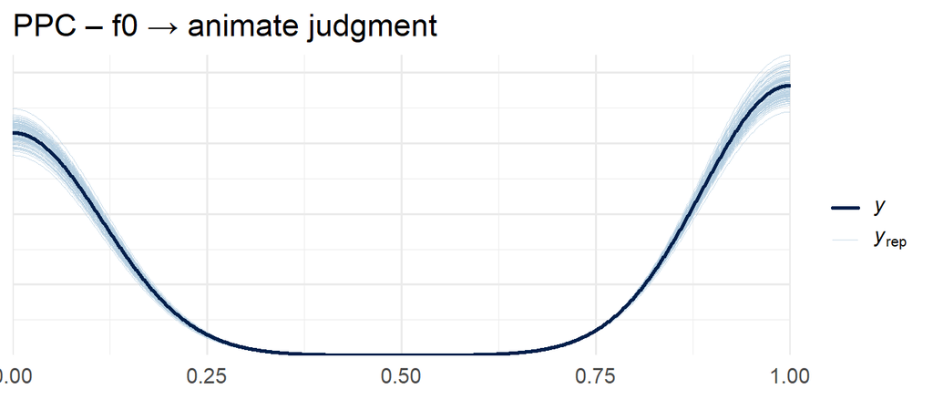

**Figure 34.** Perception: f0 as cue to animacy judgment.

```r
pp_check(m_anim_f0, ndraws = 100) + ggtitle("PPC – f0 → animate judgment")
```

## 7.6 A note on multinomial category judgments

A logical extension would be to model the full 6-way `picked_category` outcome (bird, mammal, reptile, appliance, vehicle, instrument) as a multinomial response to the same acoustic cues. We considered this and decided against including it in the main analysis for two reasons. First, a categorical 6-level outcome multiplies the coefficient space (5 contrasts × every fixed effect) and is hard to summarize compactly in a short-format paper. Second, it does not speak directly to our expectations: the size question is covered by §6, and the animacy question is covered by §6 (for animacy as production-side baseline) and §7.5 (for animacy as a perceptual outcome on its own). The chunk below is left in the script for transparency – it can be turned on by setting `eval=TRUE` – but is not part of the reported analysis. The model also does not add a parallel f0 version because the animacy-judgment perception model in §7.5 already captures the relevant question for that channel.

```r
m_cat_dur <- fit_brm(
  bf(picked_category ~ vowel_dur_ms_mean_z * animacy_c +
       (1 | listener) + (1 | speaker) + (1 | item_english)),
  data   = perc |> filter(!is.na(vowel_dur_ms_mean_z)) |>
                   mutate(picked_category = factor(picked_category)),
  family = categorical(),
  file   = paste0(models, "m_cat_dur")
)
```

## 7.7 Exploratory takeaways

These results are read as descriptive flags, not robust findings, and we mark the directions that look worth following up.

**Vocalic features beyond duration and f0.** F1 is credibly lower for big referents on the log scale (β = -0.06, 95% HDI [-0.10, -0.03]; ~6% lower F1 for big). Mechanistically a lower F1 can come from either a less open mouth or a higher tongue position (the two move together but not one-to-one), so the direction is at face value the *opposite* of the open-vowel-for-big stereotype – our speakers are realizing big referents with a slightly more closed or higher-tongue vocalic gesture, not a more open one. The direction also runs against Ćwiek and Fuchs (2025)’s null on lip opening and formant dispersion for object size, but the paradigms differ enough (their participants “shot” at cans of different sizes on the wall while saying *piff* or *paff*; ours imitatively portrayed both animate and inanimate referents in a carrier sentence) that we treat the contrast as hypothesis-generating rather than as evidence against their conclusion. F2 shows no credible size effect. CPP is credibly higher for big referents (β = 1.10 dB, 95% HDI [0.11, 2.11]), consistent with more periodic voicing for big-referent productions, and credibly lower for animate referents (animacy main effect β = -1.57, 95% HDI [-2.44, -0.69]) – with the same caveat as in §7.8: the animacy main effect on any of these channels may reflect item-level dimensions that travel with the animate/inanimate split rather than animacy as a feature. H1–H2 is also credibly lower for big referents (β = −1.21 dB, 95% HDI [−2.31, −0.11]) – with CPP, a converging hint that big-referent productions carry a less breathy, more pressed voice. On the perception side, listeners used neither CPP (β = −0.09, 95% HDI [−0.27, 0.09]) nor H1–H2 (β = 0.03, 95% HDI [−0.15, 0.21]) to judge size: the voice-quality channel, like vowel duration, is produced here but not decoded.

**Fricative production.** Fricative SPL is louder for big referents by roughly 3 dB (β = 3.08, 95% HDI [0.61, 5.61]) – the clearest iconic effect among the fricative measures. Fricative duration is in the size-iconic direction but its 95% HDI brushes zero (β = 0.10, 95% HDI [-0.02, 0.21]; P(β > 0) ≈ 0.95). Fricative peak frequency and centre of gravity show no credible size effect; phoneme identity, as expected, dominates both.

**Fricative perception.** Listeners use fricative duration as a cue to size (β = 0.25, 95% HDI [0.04, 0.45]) and the use is amplified for animate referents (interaction β = 0.50, 95% HDI [0.09, 0.91]). Listeners also use fricative SPL (β = 0.24, 95% HDI [0.05, 0.43]). F1, F2, fricative peak frequency, and fricative centre of gravity are not credibly used. The fricative-duration result is interesting on its own: it is a perception-side effect for a production-side feature whose production-side credibility was marginal – a pattern more often seen the other way round in this dataset.

**Animacy judgment.** Listeners judge productions as animate more often when speaker f0 is higher (β = 0.23 log-odds per +1 SD, 95% HDI [0.01, 0.45]; OR ≈ 1.26). The corresponding duration model is null (β = -0.10, 95% HDI [-0.28, 0.09]). The interaction with portrayed animacy in the f0 model is suggestive but its HDI crosses zero (β = 0.41, 95% HDI [-0.03, 0.87]). The pattern is consistent with f0 carrying both a size signal (lower f0 → bigger) and an animacy signal (higher f0 → animate), and the two are dissociable in the data.

## 7.8 Cuteness as a candidate explanation for the animacy main effect

The §6 finding that animate referents are produced with shorter vowels and higher f0 *regardless of their size* is striking but interpretively ambiguous: the animal stimuli differ from the object stimuli on more than just animacy. One obvious candidate is **perceived cuteness**: a separate group of 17 raters scored each stimulus picture for cuteness on a 1–7 scale. Cuteness covaries with animacy (animals tend to be rated cuter than appliances and vehicles) and partly with size (smaller things tend to be cuter than bigger things), so it is a plausible carrier of what the §6 animacy main effect is picking up.

The random-effects structure is unchanged. Cuteness varies only between items, so it does not enter as a varying slope at the speaker or listener level – the `(1 | item_english)` intercept still absorbs the between-item residual after cuteness is accounted for.

### 7.8.1 Augmented production models

```r
m_vdur_cute <- fit_brm(
  bf(vowel_dur_ms ~ size_c * animacy_c + cuteness_z + vowel +
       (1 + size_c | speaker) + (1 | item_english)),
  data   = vowel_long |> filter(!is.na(vowel_dur_ms), !is.na(cuteness_z)),
  family = lognormal(),
  file   = paste0(models, "m_vdur_cute")
)
```

```
## [fit_brm] Cache exists at 'm_vdur_cute.rds' – brms will reuse it if formula/data/prior match.
```

```r
m_f0_cute <- fit_brm(
  bf(f0 ~ size_c * animacy_c + cuteness_z + sex + vowel +
       (1 + size_c | speaker) + (1 | item_english)),
  data   = vowel_long |> filter(!is.na(f0), !is.na(cuteness_z)),
  family = lognormal(),
  file   = paste0(models, "m_f0_cute")
)
```

```
## [fit_brm] Cache exists at 'm_f0_cute.rds' – brms will reuse it if formula/data/prior match.
```

```r
summary(m_vdur_cute)
```

```
##  Family: lognormal
##   Links: mu = identity
## Formula: vowel_dur_ms ~ size_c * animacy_c + cuteness_z + vowel + (1 + size_c | speaker) + (1 | item_english)
##    Data: data (Number of observations: 1360)
##   Draws: 4 chains, each with iter = 8000; warmup = 4000; thin = 1;
##          total post-warmup draws = 16000
##
## Multilevel Hyperparameters:
## ~item_english (Number of levels: 36)
##               Estimate Est.Error l-95% CI u-95% CI Rhat Bulk_ESS Tail_ESS
## sd(Intercept)     0.19      0.03     0.14     0.25 1.00     5404     9507
##
## ~speaker (Number of levels: 42)
##                       Estimate Est.Error l-95% CI u-95% CI Rhat Bulk_ESS
## sd(Intercept)             0.31      0.04     0.24     0.39 1.00     3196
## sd(size_c)                0.17      0.03     0.12     0.24 1.00     7602
## cor(Intercept,size_c)     0.37      0.18    -0.01     0.68 1.00     9558
##                       Tail_ESS
## sd(Intercept)             5986
## sd(size_c)               11231
## cor(Intercept,size_c)    11596
##
## Regression Coefficients:
##                  Estimate Est.Error l-95% CI u-95% CI Rhat Bulk_ESS Tail_ESS
## Intercept            5.07      0.06     4.95     5.18 1.00     2696     4632
## size_c               0.14      0.08    -0.03     0.30 1.00     5499     8634
## animacy_c           -0.07      0.15    -0.37     0.22 1.00     4745     7519
## cuteness_z          -0.05      0.08    -0.20     0.11 1.00     5036     8350
## voweli:             -0.20      0.02    -0.25    -0.15 1.00    22030    13316
## vowelu:              0.05      0.02     0.00     0.09 1.00    23556    12444
## size_c:animacy_c     0.01      0.14    -0.27     0.29 1.00     5335     7986
##
## Further Distributional Parameters:
##       Estimate Est.Error l-95% CI u-95% CI Rhat Bulk_ESS Tail_ESS
## sigma     0.35      0.01     0.34     0.37 1.00    23527    10978
##
## Draws were sampled using sample(hmc). For each parameter, Bulk_ESS
## and Tail_ESS are effective sample size measures, and Rhat is the potential
## scale reduction factor on split chains (at convergence, Rhat = 1).
```

```r
summary(m_f0_cute)
```

```
##  Family: lognormal
##   Links: mu = identity
## Formula: f0 ~ size_c * animacy_c + cuteness_z + sex + vowel + (1 + size_c | speaker) + (1 | item_english)
##    Data: data (Number of observations: 1351)
##   Draws: 4 chains, each with iter = 8000; warmup = 4000; thin = 1;
##          total post-warmup draws = 16000
##
## Multilevel Hyperparameters:
## ~item_english (Number of levels: 36)
##               Estimate Est.Error l-95% CI u-95% CI Rhat Bulk_ESS Tail_ESS
## sd(Intercept)     0.14      0.02     0.11     0.19 1.00     4249     7684
##
## ~speaker (Number of levels: 42)
##                       Estimate Est.Error l-95% CI u-95% CI Rhat Bulk_ESS
## sd(Intercept)             0.11      0.02     0.09     0.15 1.00     3630
## sd(size_c)                0.07      0.02     0.03     0.11 1.00     4497
## cor(Intercept,size_c)    -0.53      0.25    -0.94     0.01 1.00     5169
##                       Tail_ESS
## sd(Intercept)             8037
## sd(size_c)                4725
## cor(Intercept,size_c)     5773
##
## Regression Coefficients:
##                  Estimate Est.Error l-95% CI u-95% CI Rhat Bulk_ESS Tail_ESS
## Intercept            4.80      0.05     4.70     4.91 1.00     3954     6763
## size_c              -0.16      0.06    -0.28    -0.04 1.00     3442     6136
## animacy_c            0.02      0.11    -0.20     0.24 1.00     3194     6184
## cuteness_z           0.05      0.06    -0.07     0.17 1.00     3393     6330
## sexw                 0.58      0.05     0.48     0.68 1.00     3427     5652
## voweli:              0.14      0.02     0.11     0.17 1.00    20715    13469
## vowelu:              0.21      0.01     0.18     0.24 1.00    20335    13296
## size_c:animacy_c    -0.09      0.10    -0.29     0.12 1.00     3555     6598
##
## Further Distributional Parameters:
##       Estimate Est.Error l-95% CI u-95% CI Rhat Bulk_ESS Tail_ESS
## sigma     0.22      0.00     0.21     0.23 1.00    20024    11700
##
## Draws were sampled using sample(hmc). For each parameter, Bulk_ESS
## and Tail_ESS are effective sample size measures, and Rhat is the potential
## scale reduction factor on split chains (at convergence, Rhat = 1).
```

### 7.8.2 Augmented perception models

```r
m_perc_f0_cute <- fit_brm(
  bf(big_judgment ~ f0_mean_z * animacy_c + cuteness_z +
       (1 | listener) + (1 | speaker) + (1 | item_english)),
  data   = perc |> filter(!is.na(f0_mean_z), !is.na(cuteness_z)),
  family = bernoulli(),
  file   = paste0(models, "m_perc_f0_cute")
)
```

```
## [fit_brm] Cache exists at 'm_perc_f0_cute.rds' – brms will reuse it if formula/data/prior match.
```

```r
m_anim_f0_cute <- fit_brm(
  bf(animate_judgment ~ f0_mean_z * animacy_c + cuteness_z +
       (1 | listener) + (1 | speaker) + (1 | item_english)),
  data   = perc |> filter(!is.na(f0_mean_z), !is.na(cuteness_z)),
  family = bernoulli(),
  file   = paste0(models, "m_anim_f0_cute")
)
```

```
## [fit_brm] Cache exists at 'm_anim_f0_cute.rds' – brms will reuse it if formula/data/prior match.
```

```r
summary(m_perc_f0_cute)
```

```
##  Family: bernoulli
##   Links: mu = logit
## Formula: big_judgment ~ f0_mean_z * animacy_c + cuteness_z + (1 | listener) + (1 | speaker) + (1 | item_english)
##    Data: data (Number of observations: 916)
##   Draws: 4 chains, each with iter = 8000; warmup = 4000; thin = 1;
##          total post-warmup draws = 16000
##
## Multilevel Hyperparameters:
## ~item_english (Number of levels: 36)
##               Estimate Est.Error l-95% CI u-95% CI Rhat Bulk_ESS Tail_ESS
## sd(Intercept)     1.17      0.21     0.82     1.62 1.00     4823     8385
##
## ~listener (Number of levels: 39)
##               Estimate Est.Error l-95% CI u-95% CI Rhat Bulk_ESS Tail_ESS
## sd(Intercept)     0.10      0.08     0.00     0.29 1.00     7878     5872
##
## ~speaker (Number of levels: 39)
##               Estimate Est.Error l-95% CI u-95% CI Rhat Bulk_ESS Tail_ESS
## sd(Intercept)     0.13      0.10     0.01     0.36 1.00     6720     6925
##
## Regression Coefficients:
##                     Estimate Est.Error l-95% CI u-95% CI Rhat Bulk_ESS Tail_ESS
## Intercept              -0.11      0.22    -0.55     0.33 1.00     3974     6892
## f0_mean_z              -0.52      0.13    -0.77    -0.26 1.00    15062    11868
## animacy_c               2.30      0.83     0.70     4.02 1.00     3373     6289
## cuteness_z             -1.83      0.44    -2.75    -1.01 1.00     3860     5177
## f0_mean_z:animacy_c    -0.26      0.26    -0.76     0.24 1.00    16685    13132
##
## Draws were sampled using sample(hmc). For each parameter, Bulk_ESS
## and Tail_ESS are effective sample size measures, and Rhat is the potential
## scale reduction factor on split chains (at convergence, Rhat = 1).
```

```r
summary(m_anim_f0_cute)
```

```
##  Family: bernoulli
##   Links: mu = logit
## Formula: animate_judgment ~ f0_mean_z * animacy_c + cuteness_z + (1 | listener) + (1 | speaker) + (1 | item_english)
##    Data: data (Number of observations: 916)
##   Draws: 4 chains, each with iter = 8000; warmup = 4000; thin = 1;
##          total post-warmup draws = 16000
##
## Multilevel Hyperparameters:
## ~item_english (Number of levels: 36)
##               Estimate Est.Error l-95% CI u-95% CI Rhat Bulk_ESS Tail_ESS
## sd(Intercept)     0.74      0.15     0.48     1.07 1.00     6700    10310
##
## ~listener (Number of levels: 39)
##               Estimate Est.Error l-95% CI u-95% CI Rhat Bulk_ESS Tail_ESS
## sd(Intercept)     0.21      0.14     0.01     0.51 1.00     4237     7357
##
## ~speaker (Number of levels: 39)
##               Estimate Est.Error l-95% CI u-95% CI Rhat Bulk_ESS Tail_ESS
## sd(Intercept)     0.39      0.16     0.06     0.69 1.00     3254     3276
##
## Regression Coefficients:
##                     Estimate Est.Error l-95% CI u-95% CI Rhat Bulk_ESS Tail_ESS
## Intercept               0.24      0.17    -0.10     0.58 1.00     8568    10360
## f0_mean_z               0.24      0.11     0.01     0.47 1.00    18217    13101
## animacy_c               2.24      0.59     1.11     3.43 1.00     6766     9383
## cuteness_z             -0.09      0.30    -0.69     0.51 1.00     6756     9837
## f0_mean_z:animacy_c     0.42      0.23    -0.03     0.87 1.00    17667    13509
##
## Draws were sampled using sample(hmc). For each parameter, Bulk_ESS
## and Tail_ESS are effective sample size measures, and Rhat is the potential
## scale reduction factor on split chains (at convergence, Rhat = 1).
```

### 7.8.3 Directional tests on the cuteness coefficient

```r
report_effect(m_vdur_cute,    "cuteness_z", direction = "auto",
              label = "Cuteness → vowel duration (production)")
```

```
##
## --- Cuteness → vowel duration (production)  [lognormal] ---
## Link-scale coefficient:  -0.0444   [95% HDI: -0.2013, 0.1134]
## Multiplicative effect:   0.957×  [95% HDI: 0.813×, 1.113×]
## As % change (big - small): -4.34% [95% HDI: -18.67%, 11.29%]
## P(cuteness_z < 0 | data)  =  0.7113
```

```r
report_effect(m_f0_cute,      "cuteness_z", direction = "auto",
              label = "Cuteness → f0 (production)")
```

```
##
## --- Cuteness → f0 (production)  [lognormal] ---
## Link-scale coefficient:  0.0482   [95% HDI: -0.0685, 0.1655]
## Multiplicative effect:   1.049×  [95% HDI: 0.931×, 1.176×]
## As % change (big - small): 4.94% [95% HDI: -6.94%, 17.62%]
## P(cuteness_z > 0 | data)  =  0.7904
```

```r
report_effect(m_perc_f0_cute, "cuteness_z", direction = "auto",
              label = "Cuteness → 'big' judgment (perception, f0 model)")
```

```
##
## --- Cuteness → 'big' judgment (perception, f0 model)  [bernoulli] ---
## Link-scale coefficient:  -1.8179   [95% HDI: -2.7047, -0.9791]
## Odds ratio:              0.162   [95% HDI: 0.049, 0.329]
## P(cuteness_z < 0 | data)  =  1.0000
```

```r
report_effect(m_anim_f0_cute, "cuteness_z", direction = "auto",
              label = "Cuteness → 'animate' judgment (perception, f0 model)")
```

```
##
## --- Cuteness → 'animate' judgment (perception, f0 model)  [bernoulli] ---
## Link-scale coefficient:  -0.0868   [95% HDI: -0.7053, 0.4954]
## Odds ratio:              0.917   [95% HDI: 0.460, 1.561]
## P(cuteness_z < 0 | data)  =  0.6139
```

```r
# And the animacy main effect in each augmented model – the comparison number
report_effect(m_vdur_cute,    "animacy_c", direction = "auto",
              label = "Animacy main effect on vowel duration AFTER controlling for cuteness")
```

```
##
## --- Animacy main effect on vowel duration AFTER controlling for cuteness  [lognormal] ---
## Link-scale coefficient:  -0.0735   [95% HDI: -0.3752, 0.2198]
## Multiplicative effect:   0.929×  [95% HDI: 0.677×, 1.230×]
## As % change (big - small): -7.08% [95% HDI: -32.27%, 23.04%]
## P(animacy_c < 0 | data)  =  0.6903
```

```r
report_effect(m_f0_cute,      "animacy_c", direction = "auto",
              label = "Animacy main effect on f0 AFTER controlling for cuteness")
```

```
##
## --- Animacy main effect on f0 AFTER controlling for cuteness  [lognormal] ---
## Link-scale coefficient:  0.0197   [95% HDI: -0.1939, 0.2413]
## Multiplicative effect:   1.020×  [95% HDI: 0.811×, 1.257×]
## As % change (big - small): 1.99% [95% HDI: -18.90%, 25.74%]
## P(animacy_c > 0 | data)  =  0.5736
```

```r
report_effect(m_perc_f0_cute, "animacy_c", direction = "auto",
              label = "Animacy main effect on 'big' judgment AFTER controlling for cuteness")
```

[output not shown]

```r
report_effect(m_anim_f0_cute, "animacy_c", direction = "auto",
              label = "Animacy main effect on 'animate' judgment AFTER controlling for cuteness")
```

```
##
## --- Animacy main effect on 'animate' judgment AFTER controlling for cuteness  [bernoulli] ---
## Link-scale coefficient:  2.2314   [95% HDI: 1.0653, 3.3754]
## Odds ratio:              9.312   [95% HDI: 1.871, 25.084]
## P(animacy_c > 0 | data)  =  0.9999
```

### 7.8.4 Side-by-side: animacy posterior with and without cuteness

This is the visual that answers the question. For each outcome, we overlay the posterior of the animacy main-effect coefficient from the baseline model (§§6.2–6.5, §7.5) and from the cuteness-augmented model (§§7.8.1–2). If cuteness is doing the work the animacy main effect was credited for in §6, the augmented posterior should shrink toward zero relative to the baseline.

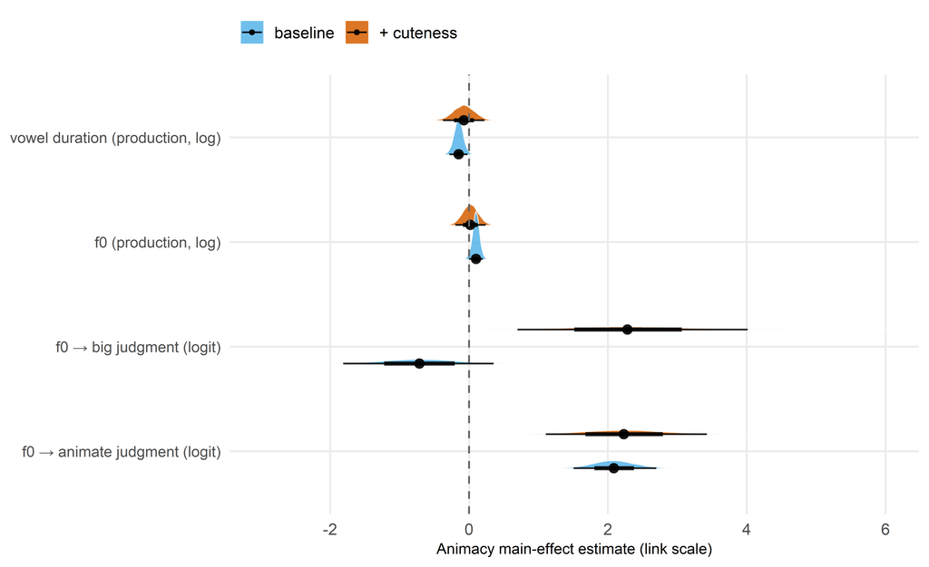

**Figure 35.** Animacy main-effect posterior in the baseline model vs. the cuteness-augmented model. Shrinkage toward zero indicates that cuteness absorbs the animacy effect.

```r
extract_animacy <- function(model, outcome_name, model_kind) {
  as_draws_df(model) |>
    transmute(outcome    = outcome_name,
              model_kind = model_kind,
              value      = b_animacy_c)
}

animacy_compare <- bind_rows(
  extract_animacy(m_vdur,         "vowel duration (production, log)", "baseline"),
  extract_animacy(m_vdur_cute,    "vowel duration (production, log)", "+ cuteness"),
  extract_animacy(m_f0,           "f0 (production, log)",             "baseline"),
  extract_animacy(m_f0_cute,      "f0 (production, log)",             "+ cuteness"),
  extract_animacy(m_perc_f0,      "f0 → big judgment (logit)",        "baseline"),
  extract_animacy(m_perc_f0_cute, "f0 → big judgment (logit)",        "+ cuteness"),
  extract_animacy(m_anim_f0,      "f0 → animate judgment (logit)",    "baseline"),
  extract_animacy(m_anim_f0_cute, "f0 → animate judgment (logit)",    "+ cuteness")
) |>
  mutate(
    outcome    = factor(outcome,    levels = unique(outcome)),
    model_kind = factor(model_kind, levels = c("baseline", "+ cuteness"))
  )
ggplot(animacy_compare,
       aes(x = value, y = fct_rev(outcome), fill = model_kind)) +
  stat_halfeye(
    .width         = c(0.66, 0.95),
    alpha          = 0.85,
    slab_colour    = "white",       # fixed, not mapped — kills the 2nd legend
    slab_linewidth = 0.3,
    position       = position_dodge(width = 0.65)
  ) +
  geom_vline(xintercept = 0, linetype = 2, colour = "grey40") +
  scale_fill_manual(values = colorBlindBlack8[c(3, 7)]) +
  labs(
    x        = "Animacy main-effect estimate (link scale)",
    y        = NULL,
    fill     = NULL#,
    #title    = "Does cuteness absorb the animacy main effect?",
    #subtitle = "Each outcome: baseline model (§6 / §7.5) vs. with cuteness_z added"
  ) +
  theme(
    plot.title          = element_text(size = 13, face = "bold"),
    plot.subtitle       = element_text(size = 10, colour = "grey30"),
    plot.title.position = "plot",          # lets title use the full plot width
    legend.position     = "top",
    legend.justification = "left",
    axis.text.y         = element_text(size = 10.5),
    axis.title.x        = element_text(size = 10.5),
    panel.grid.minor    = element_blank()
  )
```

```r
cute_forest <- bind_rows(
  extract_term(m_vdur_cute,    "cuteness_z", "vowel duration (production, log)"),
  extract_term(m_f0_cute,      "cuteness_z", "f0 (production, log)"),
  extract_term(m_perc_f0_cute, "cuteness_z", "f0 → big judgment (logit)"),
  extract_term(m_anim_f0_cute, "cuteness_z", "f0 → animate judgment (logit)")
) |>
  mutate(model = factor(model, levels = unique(model)))
```

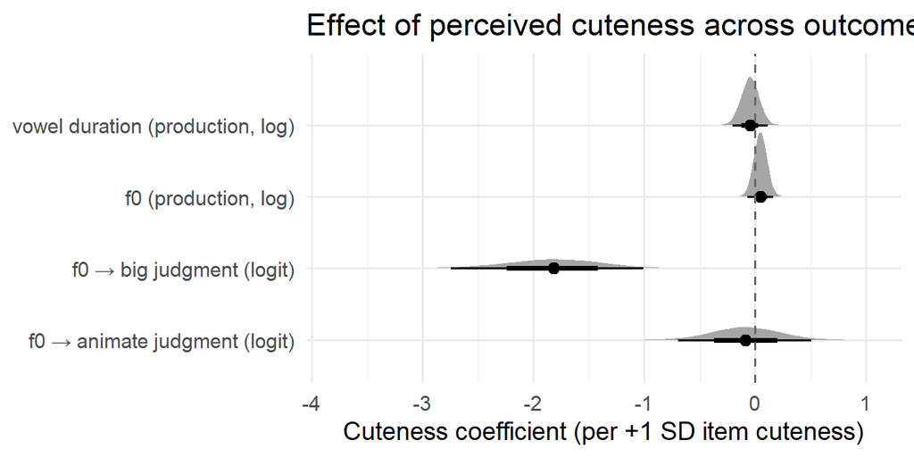

```r
ggplot(cute_forest, aes(x = value, y = fct_rev(model))) +
  stat_halfeye(.width = c(0.66, 0.95)) +
  geom_vline(xintercept = 0, linetype = 2, colour = "grey40") +
  labs(x = "Cuteness coefficient (per +1 SD item cuteness)",
       y = NULL,
       title = "Effect of perceived cuteness across outcomes")
```

### 7.8.6 Reading

**Production: animacy shrinks, but cuteness doesn’t replace it.** The animacy main effect on both production outcomes shrinks toward zero when cuteness enters the model. On vowel duration, the baseline coefficient (β = −0.15, 95% HDI [−0.28, −0.02]) becomes β = −0.07 [−0.38, 0.22] – the point estimate halves and the HDI widens to straddle zero. On f0, the baseline coefficient (β = +0.10, 95% HDI [0.00, 0.20]) becomes β = +0.02 [−0.19, 0.24]. But the cuteness coefficient does *not* take over the variance the animacy effect lost: cuteness on duration is β = −0.04 [−0.20, 0.11] (P(β < 0) = 0.71) and cuteness on f0 is β = +0.05 [−0.07, 0.17] (P(β > 0) = 0.79). Neither predictor reaches credibility in the augmented models.

The cleanest read is that animacy and cuteness are too tightly correlated in this stimulus set (§3.4 already shows that animals are systematically cuter than objects) to be separately identified from 36 items’ worth of between-item variance. The §6 animacy main effect on production is therefore fragile under any item-level covariate that tracks the animal-vs-object distinction; we cannot tell from the present data whether the carrier is animacy *qua* feature, cuteness, or a third item-level dimension confounded with both.

The animate-judgment model is, by contrast, almost untouched by adding cuteness: animacy stays at β ≈ +2.2 in both baseline and augmented fits, and cuteness is null (β = −0.09 [−0.71, 0.49]). This is the expected pattern when the outcome and a fixed effect index nearly the same thing – listeners judge animals as animate from the picture, and there is correspondingly little residual room for an item-level cuteness covariate to add explanatory value.

**The §6 size effects are unaffected.** A useful side check from the augmented production models: the size effect on vowel duration (β = +0.14 [−0.03, 0.30]) and on f0 (β = −0.16 [−0.28, −0.04]) barely move from their §6 values (+0.16 and −0.18 respectively), and the perception-of-f0 effect (β = −0.52) is unchanged. The primary §6 claims – that speakers reliably lengthen vowels and lower f0 for big referents, and that listeners use f0 to call “big” – are therefore not contaminated by item-level cuteness or animacy. Size iconicity rides on top of these between-item dimensions, not through them.

**Bottom line for the §6 animacy story.** The cuteness analysis does not cleanly support the §6 reading of an animacy main effect, but it also does not cleanly support a “cuteness in disguise” alternative. What it does support is the limitation already flagged in §9: in this stimulus set, animacy is confounded with item-level dimensions (cuteness being one we can name) to a degree that the present design cannot resolve. The honest write-up is to keep §6 as a descriptive observation – animate referents in this set were produced with shorter vowels and higher f0, and listener big-judgments tracked f0 – without claiming animacy *qua* feature as the carrier of the production-side baseline shift. A design that orthogonalises animacy and cuteness, with more items per cell, would be needed to identify either independently.

# 8. Cross-feature comparison

The three forest plots below give the visual synthesis of §§6–7. The first asks where size leaks into the produced signal across all ten acoustic features we measured. The second asks which of those features listeners use to judge size. The third looks at the same question for animacy judgments instead of size judgments. Each panel is on its own scale (log multiplicative effects, dB, Hz, or log-odds) – the comparisons within a panel are meaningful; the comparisons across panels are not.

## 8.1 Production: where does size leak into the signal?

```r
forest_prod <- bind_rows(
  extract_term(m_vdur,  "size_c", "vowel duration (log)"),
  extract_term(m_f0,    "size_c", "f0 (log)"),
  extract_term(m_F1,    "size_c", "F1 (log)"),
  extract_term(m_F2,    "size_c", "F2 (log)"),
  extract_term(m_fdur,  "size_c", "fricative duration (log)"),
  extract_term(m_CPP,   "size_c", "CPP (dB)"),
  extract_term(m_H1H2,  "size_c", "H1–H2 (dB)"),
  extract_term(m_fSPL,  "size_c", "fricative SPL (dB)"),
  extract_term(m_fpeak, "size_c", "fricative peak (Hz)"),
  extract_term(m_fCoG,  "size_c", "fricative CoG (Hz)")
) |>
  mutate(
    scale_group = case_when(
      str_detect(model, "\\(log\\)") ~ "Log scale (lognormal models)",
      str_detect(model, "\\(dB\\)")  ~ "dB scale (Gaussian)",
      str_detect(model, "\\(Hz\\)")  ~ "Hz scale (Gaussian)"
    ),
    scale_group = factor(scale_group,
                         levels = c("Log scale (lognormal models)",
                                    "dB scale (Gaussian)",
                                    "Hz scale (Gaussian)")),
    model = factor(model, levels = unique(model))
  )
```

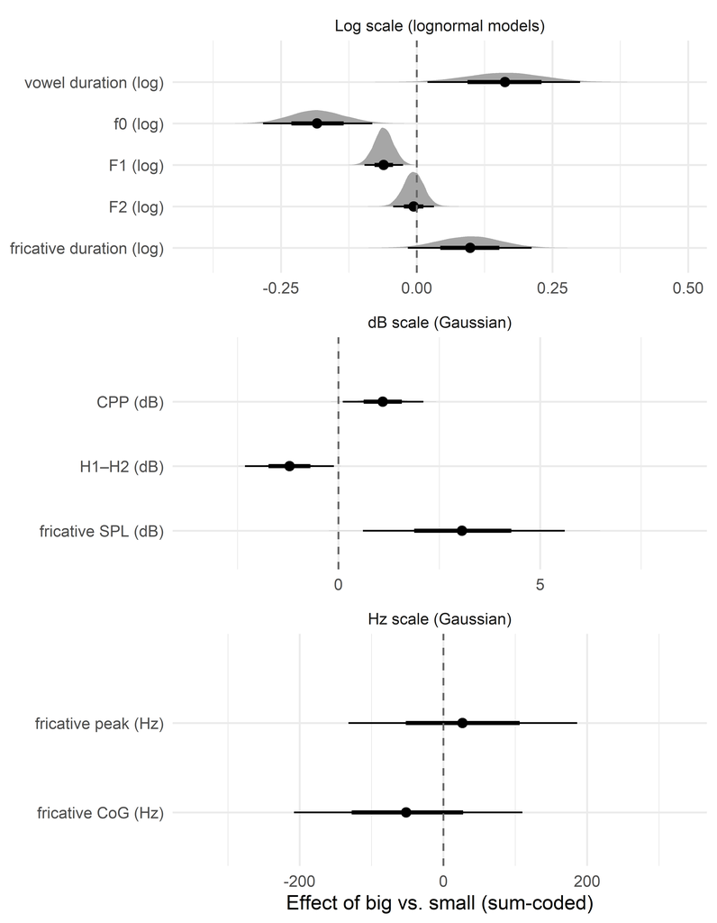

**Figure 37.** Production: size effect across all acoustic features, faceted by effect-size scale (log, dB, Hz). Each panel has its own x-axis range – magnitudes across panels are NOT directly comparable.

```r
ggplot(forest_prod, aes(x = value, y = fct_rev(model))) +
  stat_halfeye(.width = c(0.66, 0.95)) +
  geom_vline(xintercept = 0, linetype = 2, colour = "grey40") +
  facet_wrap(~ scale_group, scales = "free", ncol = 1) +
  labs(x = "Effect of big vs. small (sum-coded)",
       y = NULL#,
       #title = "Production: size effect across all acoustic features",
       #subtitle = "Top panel includes the primary-claim outcomes (vowel duration, f0)"
       )
```

## 8.2 Perception: which cues drive “big” judgments?

```r
forest_perc <- bind_rows(
  extract_term(m_perc_dur,   "vowel_dur_ms_mean_z", "vowel duration"),
  extract_term(m_perc_f0,    "f0_mean_z",           "f0"),
  extract_term(m_perc_F1,    "F1_mean_z",           "F1"),
  extract_term(m_perc_F2,    "F2_mean_z",           "F2"),
  extract_term(m_perc_CPP,   "CPP_mean_z",          "CPP"),
  extract_term(m_perc_H1H2,  "H1H2_mean_z",         "H1–H2"),
  extract_term(m_perc_fCoG,  "fric_CoG_Hz_mean_z",  "fricative CoG"),
  extract_term(m_perc_fdur,  "fric_dur_ms_mean_z",  "fricative duration"),
  extract_term(m_perc_fSPL,  "fric_SPL_dB_mean_z",  "fricative SPL"),
  extract_term(m_perc_fpeak, "fric_peak_Hz_mean_z", "fricative peak")
) |>
  mutate(model = factor(model, levels = unique(model)))
```

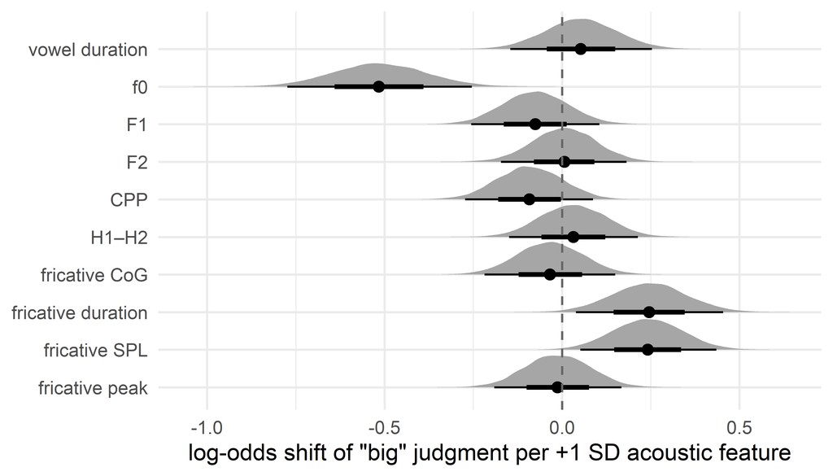

**Figure 38.** Perception: log-odds shift in ‘big’ judgment per +1 SD of each acoustic feature. Top two rows = primary claim; below = exploratory.

```r
ggplot(forest_perc, aes(x = value, y = fct_rev(model))) +
  stat_halfeye(.width = c(0.66, 0.95)) +
  geom_vline(xintercept = 0, linetype = 2, colour = "grey40") +
  labs(x = "log-odds shift of \"big\" judgment per +1 SD acoustic feature",
       y = NULL#,
       #title = "Perception: which cues drive \"big\" judgments?",
       #subtitle = "Top two rows = primary claim; below = exploratory"
       )
```

## 8.3 Perception: which cues drive “animate” judgments?

```r
forest_anim <- bind_rows(
  extract_term(m_anim_dur, "vowel_dur_ms_mean_z", "vowel duration"),
  extract_term(m_anim_f0,  "f0_mean_z",           "f0")
) |>
  mutate(model = factor(model, levels = unique(model)))
```

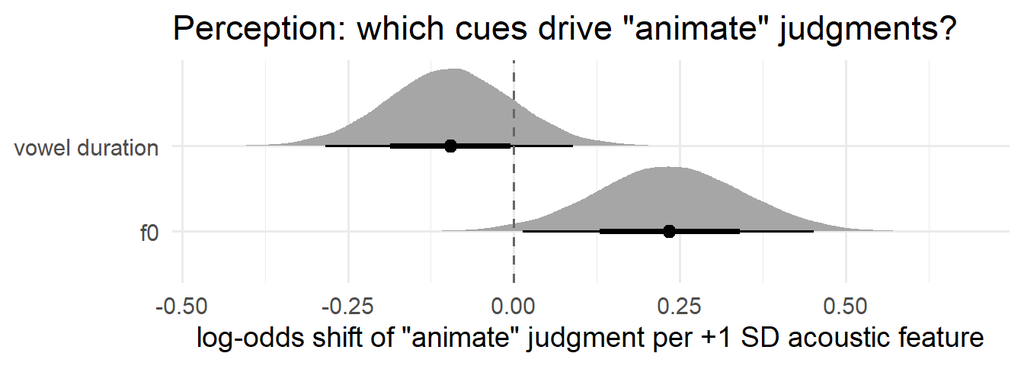

**Figure 39.** Perception: log-odds shift in ‘animate’ judgment per +1 SD of speaker vowel duration or f0.

```r
ggplot(forest_anim, aes(x = value, y = fct_rev(model))) +
  stat_halfeye(.width = c(0.66, 0.95)) +
  geom_vline(xintercept = 0, linetype = 2, colour = "grey40") +
  labs(x = "log-odds shift of \"animate\" judgment per +1 SD acoustic feature",
       y = NULL,
       title = "Perception: which cues drive \"animate\" judgments?")
```

# 9. Discussion and limitations

The data support a partly asymmetric picture of size iconicity. On the production side, both predicted channels work – speakers reliably lengthen vowels and lower f0 for big referents. On the perception side only f0 closes the loop: listeners rely on f0 to call “big”, but they do not use vowel duration even though speakers reliably produce it. The duration channel is production-only in this dataset. This asymmetry is the kind of pattern a pluripotential view of iconic features would predict (different speakers and different listeners can recruit different acoustic channels to convey or recover the same semantic dimension), but a directed replication would be needed to take it as more than suggestive.

Animacy entered the production models as a main effect rather than as a modulator of the size effect: animate referents in this stimulus set were produced with shorter vowels and higher f0 regardless of their size, with the size effect itself essentially unchanged across the animate/inanimate split. We treat this as a descriptive observation rather than as evidence for animacy qua feature. A separately-collected per-item cuteness rating (§7.8) provides the cleanest available diagnostic: when cuteness is added as a covariate to the production models, the animacy main effect shrinks toward zero, but cuteness itself does not take its place – both predictors become non-credible. The honest read is that animals and objects in this stimulus set differ acoustically in ways that go beyond their size, but that the 36-item design lacks the resolution to identify which item-level dimension is responsible. Listeners’ “animate” judgments, separately, are modulated by speaker f0 (§7.5), and this perception pattern survives the cuteness control (§7.8) unchanged.

The exploratory channels are descriptive: CPP and F1 in production, and fricative duration and fricative SPL in perception, all show credible effects that are worth a closer look in a study designed around them. We flag them rather than claim them.

Three limitations are worth naming. (i) The stimulus set is small (36 items) and confounds size with referent identity – speaker-level random effects help but cannot fully partial this out. (ii) Listeners had a picture in front of them, so item identity is the dominant driver of any judgment; the acoustic cues modulate on top of an already strong prior (see the item-level baselines in §6.7). (iii) Animacy is confounded with item-level dimensions of the stimulus set – a separately-collected cuteness rating (§7.8) is one such dimension, and likely not the only one – to a degree that the present 36-item design cannot resolve. A design that orthogonalises animacy and cuteness (and ideally other item-level dimensions that travel with the animal/object split, such as baseline expressiveness or articulatory complexity), with more items per cell, would be needed to identify animacy as a semantic feature in production.

# 10. References

Akita, Kimi, Bonnie McLean, Jiyeon Park, and Arthur Lewis Thompson. 2024. “Iconicity Mediates Semantic Networks of Sound Symbolism.” *The Journal of the Acoustical Society of America* 155 (4): 2687–97. https://doi.org/10.1121/10.0025763.

Al-Tamimi, Jalal. 2022. “JalalAl-Tamimi/Praat-Spectral-Analyses-Fricatives-Stops: Praat Spectral Analyses.” Zenodo. https://doi.org/10.5281/ZENODO.7270187.

Blasi, Damián E., Søren Wichmann, Harald Hammarström, Peter F. Stadler, and Morten H. Christiansen. 2016. “Sound–Meaning Association Biases Evidenced Across Thousands of Languages.” *Proceedings of the National Academy of Sciences* 113 (39): 10818–23. https://doi.org/10.1073/pnas.1605782113.

Boersma, Paul, and David Weenink. 2023. “Praat. Doing Phonetics by Computer.”

Chai, Yuan, and Marc Garellek. 2022. “On H1–H2 as an Acoustic Measure of Linguistic Phonation Type.” *The Journal of the Acoustical Society of America* 152 (3): 1856–70. https://doi.org/10.1121/10.0014175.

Ćwiek, Aleksandra. 2022. “Iconicity in Language and Speech.” Humboldt-Universität zu Berlin. https://doi.org/10.18452/24544.

Ćwiek, Aleksandra, and Susanne Fuchs. 2025. “The Scope and Limits of Iconic Prosody: Head Angle Predicts F0 Changes While Object Size Effects Are Absent.” *Open Mind* 9: 1959–81. https://doi.org/10.1162/OPMI.a.251.

Ćwiek, Aleksandra, Jody Kreiman, and Susanne Fuchs. 2025. “Introduction to the Special Issue on Iconicity and Sound Symbolism.” *The Journal of the Acoustical Society of America* 157 (5): 3806–13. https://doi.org/10.1121/10.0036662.

Dingemanse, Mark, Damián E. Blasi, Gary Lupyan, Morten H. Christiansen, and Padraic Monaghan. 2015. “Arbitrariness, Iconicity, and Systematicity in Language.” *Trends in Cognitive Sciences* 19 (10): 603–15. https://doi.org/10.1016/j.tics.2015.07.013.

Fraile, Rubén, and Juan Ignacio Godino-Llorente. 2014. “Cepstral Peak Prominence: A Comprehensive Analysis.” *Biomedical Signal Processing and Control* 14 (November): 42–54. https://doi.org/10.1016/j.bspc.2014.07.001.

Fuchs, Susanne, and Aleksandra Ćwiek. 2022. “Sounds Full of Meaning and the Evolution of Language.” *Acoustics Today* 18 (2): 43. https://doi.org/10.1121/AT.2022.18.2.43.

Hillenbrand, James, Ronald A. Cleveland, and Robert L. Erickson. 1994. “Acoustic Correlates of Breathy Vocal Quality.” *Journal of Speech, Language, and Hearing Research* 37 (4): 769–78. https://doi.org/10.1044/jshr.3704.769.

Jongman, Allard, Ratree Wayland, and Serena Wong. 2000. “Acoustic Characteristics of English Fricatives.” *The Journal of the Acoustical Society of America* 108 (3): 1252–63.

Kirby, James, and Rasmus Puggaard-Rode. 2025. “PraatSauce. Praat-Based Tools for Spectral Processing.” kirbyj.github.io/praatsauce.

Ohala, John J. 1983. “Cross-Language Use of Pitch: An Ethological View.” *Phonetica* 40 (1): 1–18.

———. 1984. “An Ethological Perspective on Common Cross-Language Utilization of F₀ of Voice.” *Phonetica* 41 (1): 1–16.

Perlman, Marcus, Hannah Little, Bill Thompson, and Robin L. Thompson. 2018. “Iconicity in Signed and Spoken Vocabulary: A Comparison Between American Sign Language, British Sign Language, English, and Spanish.” *Frontiers in Psychology* 9 (August): 1433. https://doi.org/10.3389/fpsyg.2018.01433.

Perniss, Pamela, and Gabriella Vigliocco. 2014. “The Bridge of Iconicity: From a World of Experience to the Experience of Language.” *Philosophical Transactions of the Royal Society B: Biological Sciences* 369 (1651): 20130300. https://doi.org/10.1098/rstb.2013.0300.

Sapir, E. 1929. “A Study in Phonetic Symbolism.” *Journal of Experimental Psychology* 12 (3): 225–39. https://doi.org/10.1037/h0070931.

Schmidt, Alexandra, and Farhat Jabeen. 2024. “What Noise Does a Dragon Make? Iconicity in Non-Word Vocalisations.” https://drive.google.com/file/d/1akwZ9e9s-rsP281rxVSDr9753-EpCznf/view.

Winter, Bodo. 2021. “Iconicity, Not Arbitrariness, Is a Design Feature of Language.” Abralin Ao Vivo (online lecture, hosted by Abralin). https://youtu.be/R1ETw21oCGE.

———. 2025. “The Size and Shape of Sound: The Role of Articulation and Acoustics in Iconicity and Crossmodal Correspondences.” *The Journal of the Acoustical Society of America* 157 (4): 2636–56. https://doi.org/10.1121/10.0036362.

Winter, Bodo, and Marcus Perlman. 2021. “Size Sound Symbolism in the English Lexicon.” *Glossa: A Journal of General Linguistics* 6 (1). https://doi.org/10.5334/gjgl.1646.